# Impact of Outliers on Measures of Location

Barbara Sánchez

2025-08-13

# 1. Introducción

El trabajo actual ha sido realizado con fines de estudio, para poder ver el impacto que tienen los outliers sobre la media, mediana y moda.

- Número de variables: 2
- Número de observaciones: 100

# 2. Objetivos

- Calcular y representar gráficamente la media, mediana y moda
- Visualizar y comprender el impacto que tienen los outliers sobre la media, mediana y moda.

# 3. Configuración

Instalamos los paquetes y cargamos las librerías necesarias.

```r
# Install necessary packages and libraries

#install.packages("tidyverse")
#install.packages("ggplot2")
#install.packages("dplyr")
library(readr)
library(dplyr)
library(ggplot2)
```

# 4. Creación del data frame

```r
# Read raw
mark <- c(6, 7, 8, 9, 10, 11, 12, 13, 14, 15,
             16, 17, 18, 19, 20, 21, 22, 23, 24, 25,
             27, 28, 30, 31, 32, 36, 37, 38, 40, 41,
             42, 44, 46, 50, 51, 52, 53, 54)
freqs <- c(5, 3, 3, 4, 2, 4, 3, 4, 2, 1,
                 3, 5, 4, 4, 5, 2, 2, 2, 6, 1,
                 2, 2, 1, 3, 1, 1, 2, 2, 4, 3,
                 2, 2, 1, 1, 3, 1, 3, 1)
mark <- rep(mark, freqs)

df <- data.frame(
  student = as.character(seq(1, 100)),
  mark = mark
)
```

# 5. Exploración inicial (EDA básico)

```r
# First six lines of the df
head(df)
```

|  | student | mark |
| --- | --- | --- |
| 1 | 1 | 6 |
| 2 | 2 | 6 |
| 3 | 3 | 6 |
| 4 | 4 | 6 |
| 5 | 5 | 6 |
| 6 | 6 | 7 |

```r
# Internal structure of the df
glimpse(df)
```

```
Rows: 100
Columns: 2
$ student <chr> "1", "2", "3", "4", "5", "6", "7", "8…
$ mark    <dbl> 6, 6, 6, 6, 6, 7, 7, 7, 8, 8, 8, 9, 9…
```

```r
# Statistical summary
summary(df)
```

```
   student               mark
 Length:100         Min.   : 6.00
 Class :character   1st Qu.:13.00
 Mode  :character   Median :20.00
                    Mean   :24.08
                    3rd Qu.:36.25
                    Max.   :54.00
```

```r
# Test for NAs

anyNA(df)
```

```
[1] FALSE
```

```r
sum(is.na(df))
```

```
[1] 0
```

```r
# Freq by obs
table(df$mark)
```

```
 6  7  8  9 10 11 12 13 14 15 16 17 18 19 20 21 22 23
 5  3  3  4  2  4  3  4  2  1  3  5  4  4  5  2  2  2
24 25 27 28 30 31 32 36 37 38 40 41 42 44 46 50 51 52
 6  1  2  2  1  3  1  1  2  2  4  3  2  2  1  1  3  1
53 54
 3  1
```

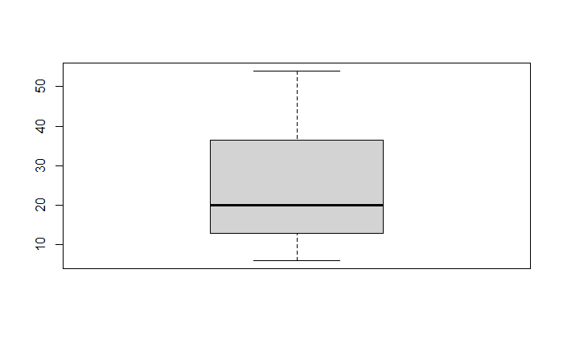

```r
# Looking for outliers
boxplot(df$mark)
```

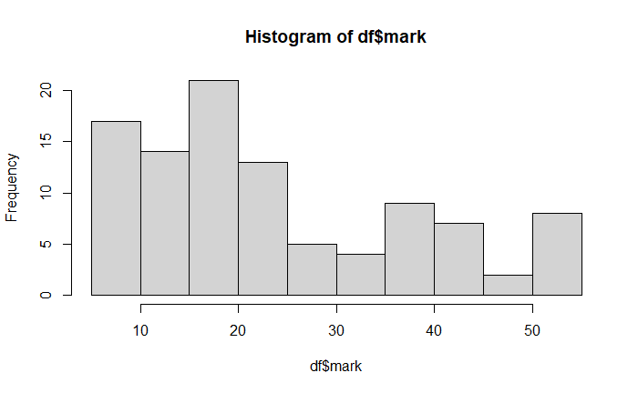

```r
# How's the data
hist(df$mark)
```

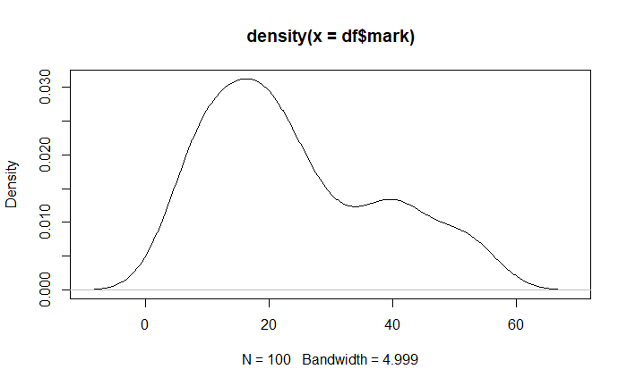

```r
# How's the data
plot(density(df$mark))
```

# 6. Medidas de localización

Cálculo de la media, mediana y moda respecto a la variable mark.

## 6.1 Media

```r
# Calculate mean

media <- mean(df$mark, na.rm = TRUE)

print(round(media,1))
```

```
[1] 24.1
```

## 6.2 Mediana

```r
# Calculate median

mediana <- median(df$mark, na.rm = TRUE)
print(round(mediana, 1))
```

```
[1] 20
```

## 6.3 Moda

```r
# Calculate mode
# In a bimodal or multimodal situation, it only returns the lowest mode.

freq_table <- table(df$mark)
moda <- min(as.numeric(names(freq_table)[freq_table == max(freq_table)]))
print(round(moda, 1))
```

```
[1] 24
```

## 6.4 Visualizamos la media, mediana y moda:

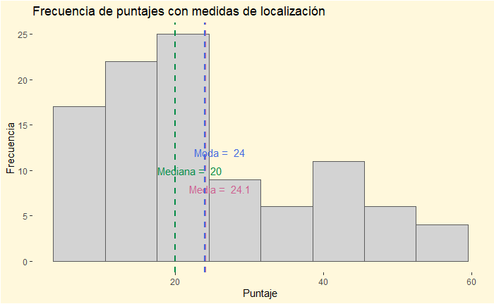

```r
ggplot(df, aes(x = mark)) +
  geom_histogram(binwidth = 7, fill = "lightgray", color = "gray36") +
  # Media
  geom_vline(aes(xintercept = media), color = "#CD6090", linetype = "dashed", size = 1) +
  annotate("text", x = media + 2, y = 8, label = paste("Media = ", round(media, 1)), color = "#CD6090") +
  # Mediana
  geom_vline(aes(xintercept = mediana), color = "#008B45", linetype = "dashed", size = 1) +
  annotate("text", x = mediana + 2, y = 10, label = paste("Mediana = ", round(mediana, 1)), color = "#008B45") +
  # Moda
  geom_vline(aes(xintercept = moda), color = "#4169E1", linetype = "dashed", size = 1) +
  annotate("text", x = moda + 2, y = 12, label = paste("Moda = ", round(moda, 1)), color = "#4169E1") +
  # Etiquetas
  labs(title = "Frecuencia de puntajes con medidas de localización", x = "Puntaje", y = "Frecuencia") +
  # Fondo personalizado
  theme(
    panel.background = element_rect(fill = "#FFF8DC"),  # Fondo del panel
    plot.background = element_rect(fill = "#FFF8DC"),   # Fondo total del gráfico
    panel.grid.major = element_line(color = "#FFF8DC"),   # Líneas de cuadrícula principales
    panel.grid.minor = element_line(color = "#FFF8DC")    # Líneas de cuadrícula menores
  )
```

# 7. Impacto de outliers en las medidas de localización

## 7.1 Dataset con outliers en mark

```r
# Copy the df

df_outliers <- df

# Add outliers

df_outliers <- rbind(df_outliers, data.frame(
                                              student = c("a", "b"),
                                              mark = c(100, 99)
)
)

# Show the changes
tail(df_outliers)
```

|  | student | mark |
| --- | --- | --- |
| 97 | 97 | 53 |
| 98 | 98 | 53 |
| 99 | 99 | 53 |
| 100 | 100 | 54 |
| 101 | a | 100 |
| 102 | b | 99 |

## 7.2 Media

```r
# Calculate mean

media_out <- mean(df_outliers$mark, na.rm = TRUE)

print(round(media_out, 1))
```

```
[1] 25.6
```

## 7.3 Mediana

```r
# Calculate median
mediana_out <- median(df_outliers$mark, na.rm = TRUE)
print(round(mediana_out, 1))
```

```
[1] 20
```

## 7.4 Moda

```r
# Calculate mode
# In a bimodal or multimodal situation, it only returns the lowest mode.

freq_table_out <- table(df_outliers$mark)
moda_out <- min(as.numeric(names(freq_table_out)[freq_table_out == max(freq_table_out)]))
print(round(moda_out, 1))
```

```
[1] 24
```

## 7.5 Visualizamos el impacto de los outliers sobre la media, mediana y moda :

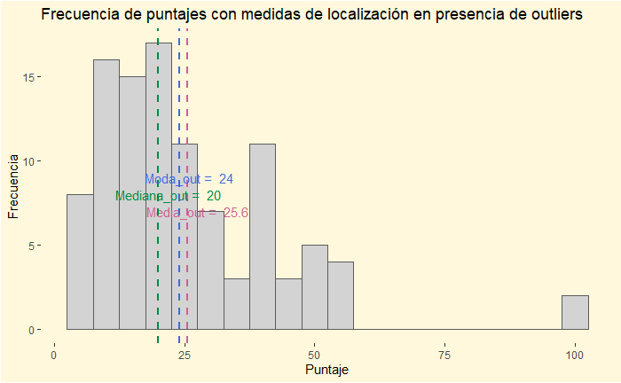

```r
ggplot(df_outliers, aes(x = mark)) +
  geom_histogram(binwidth = 5, fill = "lightgray", color = "gray36") +
  # Mean
  geom_vline(aes(xintercept = media_out), color = "#CD6090", linetype = "dashed", size = 1) +
  annotate("text", x = media_out + 2, y = 7, label = paste("Media_out = ", round(media_out, 1)), color = "#CD6090") +
  # Median
  geom_vline(aes(xintercept = mediana_out), color = "#008B45", linetype = "dashed", size = 1) +
  annotate("text", x = mediana_out + 2, y = 8, label = paste("Mediana_out = ", round(mediana_out, 1)), color = "#008B45") +
  # Mode
  geom_vline(aes(xintercept = moda_out), color = "#4169E1", linetype = "dashed", size = 1) +
  annotate("text", x = moda_out + 2, y = 9, label = paste("Moda_out = ", round(moda_out, 1)), color = "#4169E1") +
  # Labels
  labs(title = "Frecuencia de puntajes con medidas de localización en presencia de outliers", x ="Puntaje", y ="Frecuencia")+
  # Fondo personalizado
  theme(
    panel.background = element_rect(fill = "#FFF8DC"),  # Fondo del panel
    plot.background = element_rect(fill = "#FFF8DC"),   # Fondo total del gráfico
    panel.grid.major = element_line(color = "#FFF8DC"),   # Líneas de cuadrícula principales
    panel.grid.minor = element_line(color = "#FFF8DC"),    # Líneas de cuadrícula menores
  )
```

# 8. Conclusiones:

- La media es la medida más afectada por la presencia de outliers, desplazándose considerablemente hacia el extremo (donde se encuentran estos outliers).
- La mediana presenta una afectación mínima por la presencia de outliers, lo cual podríamos interpretar como que es más resistente a valores extremos; por lo que es la medida más robusta ante outliers.
- La moda no se afecta por los outliers, ya que aparecen en menor cantidad que los valores con frecuencia máxima (modas).
- En análisis de datos reales, especialmente con presencia de outliers, la mediana y otras medidas robustas suelen proporcionar una descripción más representativa que la media.
- Este análisis evidencia la importancia de identificar y manejar los outliers antes de interpretar las medidas de tendencia central, especialmente cuando la media se utiliza como indicador principal en contextos educativos o de rendimiento académico.